# IODS course project

RistoH

# Introduction to Open Data Science - Course Project

# About the project

This is my page for Introduction to Open Data Science course. Feeling super excited about the course. I am especially interested in learning how to use Git in R. Earlier I have been using only TortoiseGit with SAS. I have done earlier done few R courses in DataCamp and used many online “cookbooks”.

I checked the R for Health Data Science -book and the excercise set 1. These seemed like a great crash course. The book most def goes to my list of useful R-sources.

Link to my repository: [click!](https://github.com/hurmris/IODS-project)

# 2. Regression and model validation

```r
library(tidyverse)
library(sandwich)
library(lmtest)
```

## Read the data

```r
analysis_data <- read_csv("data/learning2014.csv")
str(analysis_data)
```

```
## spc_tbl_ [166 × 7] (S3: spec_tbl_df/tbl_df/tbl/data.frame)
##  $ gender  : chr [1:166] "F" "M" "F" "M" ...
##  $ Age     : num [1:166] 53 55 49 53 49 38 50 37 37 42 ...
##  $ attitude: num [1:166] 3.7 3.1 2.5 3.5 3.7 3.8 3.5 2.9 3.8 2.1 ...
##  $ deep    : num [1:166] 3.58 2.92 3.5 3.5 3.67 ...
##  $ stra    : num [1:166] 3.38 2.75 3.62 3.12 3.62 ...
##  $ surf    : num [1:166] 2.58 3.17 2.25 2.25 2.83 ...
##  $ Points  : num [1:166] 25 12 24 10 22 21 21 31 24 26 ...
##  - attr(*, "spec")=
##   .. cols(
##   ..   gender = col_character(),
##   ..   Age = col_double(),
##   ..   attitude = col_double(),
##   ..   deep = col_double(),
##   ..   stra = col_double(),
##   ..   surf = col_double(),
##   ..   Points = col_double()
##   .. )
##  - attr(*, "problems")=<externalptr>
```

Data set includes survey data from students, source Kimmo Vehkalahti, extra info [here](https://www.mv.helsinki.fi/home/kvehkala/JYTmooc/JYTOPKYS3-meta.txt)

- Attitude is a sum of 10 questions related to students attitude towards statistics, each measured on the Likert scale (1-5)
- deep is a mean of 11 questions related to deep learning
- stra is a mean of 8 questions related to strategic learning
- surf is a mean of 10 questions related to surface learning - points are exam point (observations with points equal to zero are dropped)

## Graphical overview:

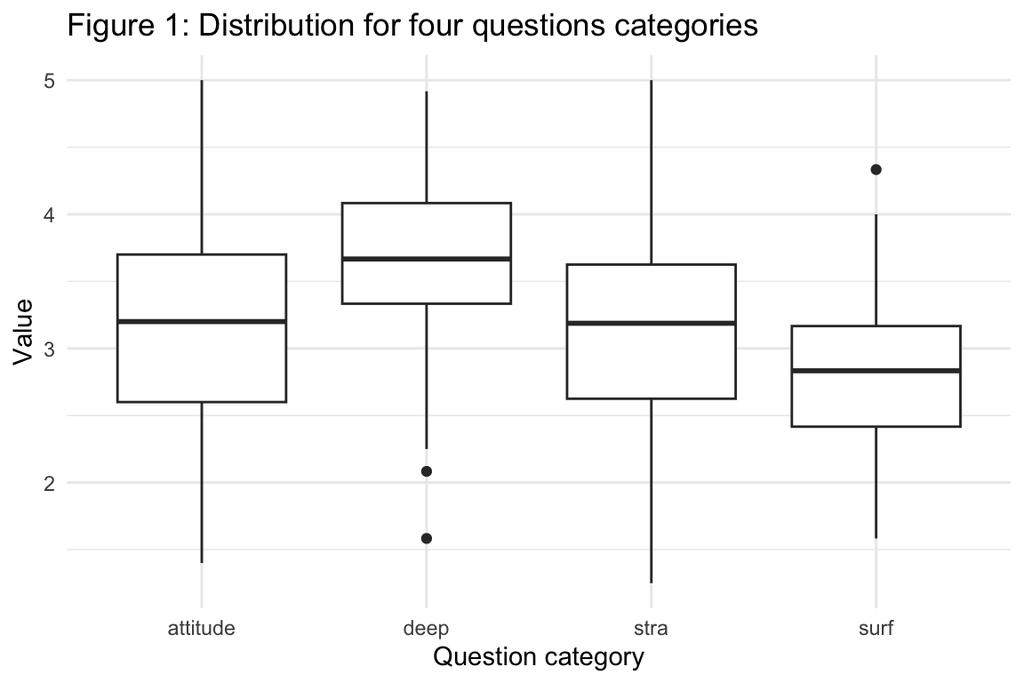

```r
data_long <- analysis_data %>% select(attitude,deep,stra,surf) %>%
  pivot_longer(everything(), names_to = "Variable")

ggplot(data_long, aes(x = Variable, y = value)) +
  geom_boxplot() +
  labs(title = "Figure 1: Distribution for four questions categories",
       x = "Question category",
       y = "Value") +
  theme_minimal()
```

Figure one plots the distributions of attitude, deep, stra and surf questions. Median value varies across roughly 2.75 to 3.75. Only deep and surf categories have some outlier observations.

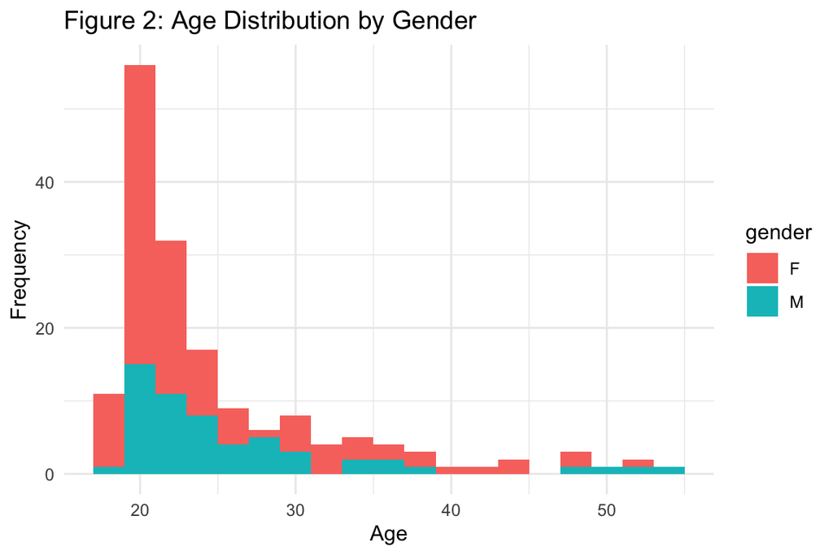

```r
ggplot(data=analysis_data,aes(x=Age, fill=gender))+
  geom_histogram(bins = 20) +
  labs(title = "Figure 2: Age Distribution by Gender", x = "Age", y = "Frequency") +
  theme_minimal()
```

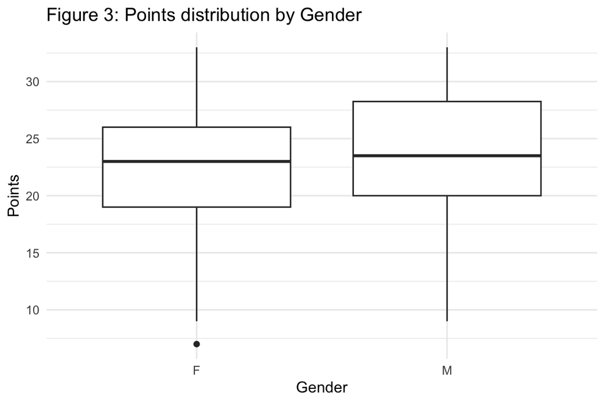

```r
ggplot(analysis_data, aes(x = gender, y = Points)) +
  geom_boxplot()+
  theme_minimal()+
  labs(title = "Figure 3: Points distribution by Gender", x = "Gender", y = "Points")
```

Figure show the distribution of points by gender. Based on this it seems that the points are distributed quite similarly acrross to gender types in the data.

## Regression model

```r
#Run model
lm1 <- lm(formula= Points ~ attitude + deep  + Age  + surf, data=analysis_data)
summary(lm1)
```

```
##
## Call:
## lm(formula = Points ~ attitude + deep + Age + surf, data = analysis_data)
##
## Residuals:
##      Min       1Q   Median       3Q      Max
## -17.6138  -3.3788   0.3136   3.7932  11.1715
##
## Coefficients:
##             Estimate Std. Error t value Pr(>|t|)
## (Intercept) 21.26552    5.00630   4.248 3.64e-05 ***
## attitude     3.46471    0.57351   6.041 1.02e-08 ***
## deep        -0.97708    0.78623  -1.243   0.2158
## Age         -0.08859    0.05353  -1.655   0.0999 .
## surf        -1.28515    0.83976  -1.530   0.1279
## ---
## Signif. codes:  0 '***' 0.001 '**' 0.01 '*' 0.05 '.' 0.1 ' ' 1
##
## Residual standard error: 5.285 on 161 degrees of freedom
## Multiple R-squared:  0.2157, Adjusted R-squared:  0.1962
## F-statistic: 11.07 on 4 and 161 DF,  p-value: 5.873e-08
```

Based on outputs above one can conclude that only statistically significant coefficient in the specification is attitude (assuming homoskedastic errors!). On average one-unit increase in the scale of attitude increases points by roughly 3.5.

- t-value tests whether the coefficient is statistically significantly different from zero
- F-statistics tests whether all of the coefficient are different from zero (jointly)

```r
lm2 <- lm(formula= Points ~ attitude, data=analysis_data)
summary(lm2)
```

```
##
## Call:
## lm(formula = Points ~ attitude, data = analysis_data)
##
## Residuals:
##      Min       1Q   Median       3Q      Max
## -16.9763  -3.2119   0.4339   4.1534  10.6645
##
## Coefficients:
##             Estimate Std. Error t value Pr(>|t|)
## (Intercept)  11.6372     1.8303   6.358 1.95e-09 ***
## attitude      3.5255     0.5674   6.214 4.12e-09 ***
## ---
## Signif. codes:  0 '***' 0.001 '**' 0.01 '*' 0.05 '.' 0.1 ' ' 1
##
## Residual standard error: 5.32 on 164 degrees of freedom
## Multiple R-squared:  0.1906, Adjusted R-squared:  0.1856
## F-statistic: 38.61 on 1 and 164 DF,  p-value: 4.119e-09
```

After excluding non-significant variables we see that is still aroung 3.5. Multiple R-squared measures the proportion of variance in the dependent variable that can be explained by the predictor variables in the model. It ranges from 0 to 1, with higher values indicating a better fit. In the output above we see that this is 0.1906 so around 20 percent.

## Diagnostic plots

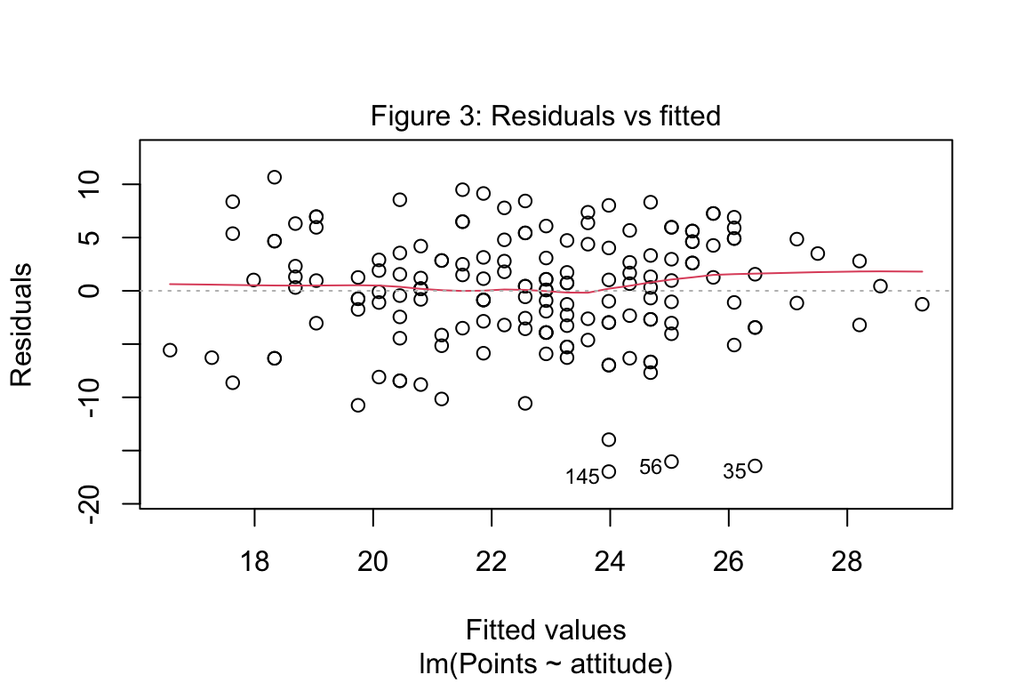

```r
# Residuals vs Fitted values
plot(lm2, which = 1,caption = "Figure 3: Residuals vs fitted")
```

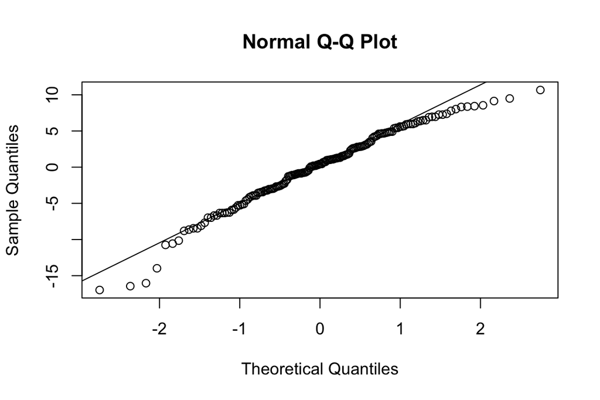

```r
qqnorm(lm2$residuals)
qqline(lm2$residuals)
```

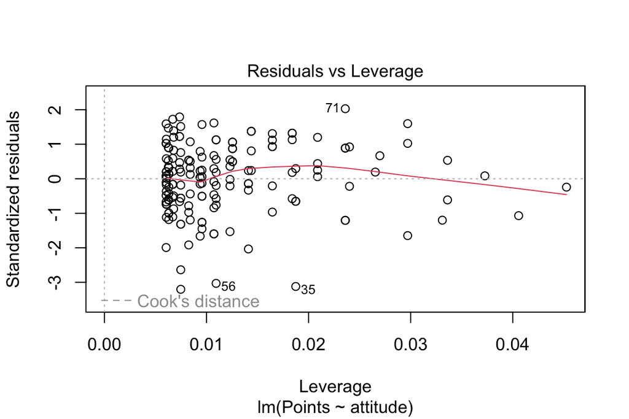

```r
plot(lm2, which = 5)
```

Model assumptions:

1. Linear relationship between predictors and outcome
2. Independence of residuals
3. Normal distribution of residuals
4. Equal variance of residuals

Validity of our assumptions:

- Based on Figure 3. the assumption on linear relationship could seem plausible
- Based on Q-Q plot we see that residuals are diverging from the line, which suggest that errors are not normally distributed
- Based on Figure 3. the assumption on equal variance seems plausible, no clear patterns that suggested otherwise.

# 3. Logistic regression

## Data description

```r
#Read data
alc <- readr::read_csv("data/alc.csv")
names(alc)
```

```
##  [1] "school"     "sex"        "age"        "address"    "famsize"
##  [6] "Pstatus"    "Medu"       "Fedu"       "Mjob"       "Fjob"
## [11] "reason"     "guardian"   "traveltime" "studytime"  "schoolsup"
## [16] "famsup"     "activities" "nursery"    "higher"     "internet"
## [21] "romantic"   "famrel"     "freetime"   "goout"      "Dalc"
## [26] "Walc"       "health"     "failures"   "paid"       "absences"
## [31] "G1"         "G2"         "G3"         "alc_use"    "high_use"
```

**The analysis includes student attributes and average of course grades for math and portuguese exams. See full full description for the variables below:**

1 school - student’s school (binary: “GP” - Gabriel Pereira or “MS” - Mousinho da Silveira) 2 sex - student’s sex (binary: “F” - female or “M” - male) 3 age - student’s age (numeric: from 15 to 22) 4 address - student’s home address type (binary: “U” - urban or “R” - rural) 5 famsize - family size (binary: “LE3” - less or equal to 3 or “GT3” - greater than 3) 6 Pstatus - parent’s cohabitation status (binary: “T” - living together or “A” - apart) 7 Medu - mother’s education (numeric: 0 - none, 1 - primary education (4th grade), 2 – 5th to 9th grade, 3 – secondary education or 4 – higher education) 8 Fedu - father’s education (numeric: 0 - none, 1 - primary education (4th grade), 2 – 5th to 9th grade, 3 – secondary education or 4 – higher education) 9 Mjob - mother’s job (nominal: “teacher”, “health” care related, civil “services” (e.g. administrative or police), “at_home” or “other”) 10 Fjob - father’s job (nominal: “teacher”, “health” care related, civil “services” (e.g. administrative or police), “at_home” or “other”) 11 reason - reason to choose this school (nominal: close to “home”, school “reputation”, “course” preference or “other”) 12 guardian - student’s guardian (nominal: “mother”, “father” or “other”) 13 traveltime - home to school travel time (numeric: 1 - <15 min., 2 - 15 to 30 min., 3 - 30 min. to 1 hour, or 4 - >1 hour) 14 studytime - weekly study time (numeric: 1 - <2 hours, 2 - 2 to 5 hours, 3 - 5 to 10 hours, or 4 - >10 hours) 15 failures - number of past class failures (numeric: n if 1<=n<3, else 4) 16 schoolsup - extra educational support (binary: yes or no) 17 famsup - family educational support (binary: yes or no) 18 paid - extra paid classes within the course subject (Math or Portuguese) (binary: yes or no) 19 activities - extra-curricular activities (binary: yes or no) 20 nursery - attended nursery school (binary: yes or no) 21 higher - wants to take higher education (binary: yes or no) 22 internet - Internet access at home (binary: yes or no) 23 romantic - with a romantic relationship (binary: yes or no) 24 famrel - quality of family relationships (numeric: from 1 - very bad to 5 - excellent) 25 freetime - free time after school (numeric: from 1 - very low to 5 - very high) 26 goout - going out with friends (numeric: from 1 - very low to 5 - very high) 27 Dalc - workday alcohol consumption (numeric: from 1 - very low to 5 - very high) 28 Walc - weekend alcohol consumption (numeric: from 1 - very low to 5 - very high) 29 health - current health status (numeric: from 1 - very bad to 5 - very good) 30 absences - number of school absences (numeric: from 0 to 93)

**Grades are average grades from math and portuguese exams:** 31 G1 - first period grade (numeric: from 0 to 20) 31 G2 - second period grade (numeric: from 0 to 20) 32 G3 - final grade (numeric: from 0 to 20, output target)

## Data analysis:

In this analysis I study the relationship of student attributes and alcohol consumption. The four attributes of interest studied are

- Medu - mother’s education
- failures - number of past class failures
- famrel quality of family relationships
- freetime - free time after school

## Hypotheses

My hypothesis is that alcohol consumption is positively correlated with number of failures and free time after school and negatively correlated with the quality of family relationships and mother’s education level.

## Descriptives

Let’s check some cross tabulations and graphs to study the relationships

### Mother’s education

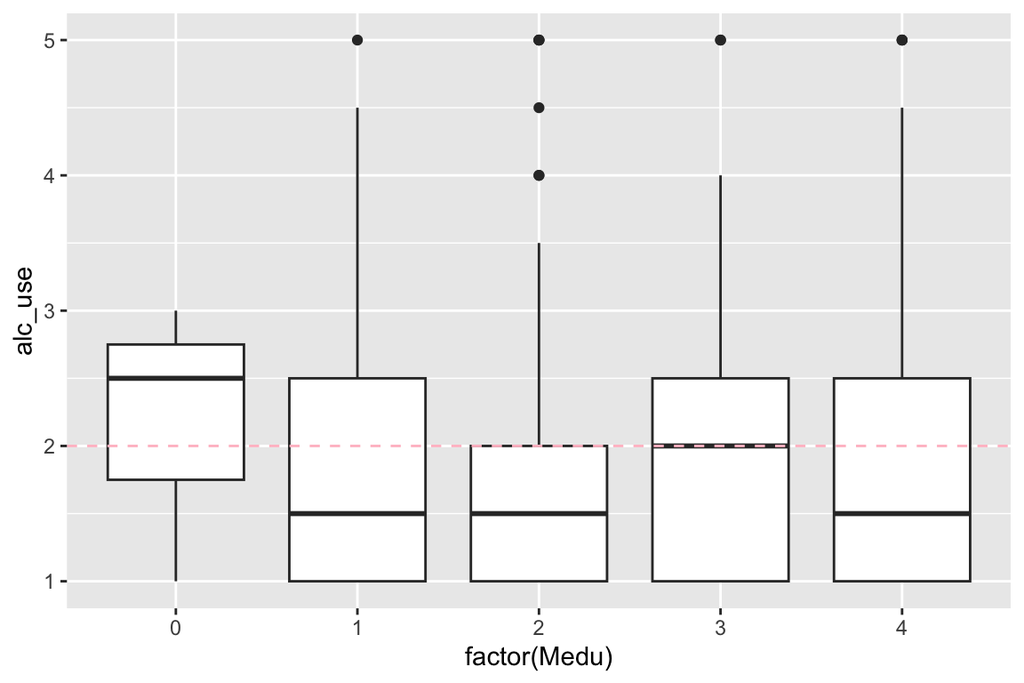

```r
ggplot(data=alc, aes(x=factor(Medu),y=alc_use))+
  geom_boxplot()+
  geom_hline(yintercept = 2,linetype="dashed", color="pink")
```

```r
  labs(y="Alcohol usage", x="Mother's education", title = "Alcohol consumption by mothers education")
```

```
## $y
## [1] "Alcohol usage"
##
## $x
## [1] "Mother's education"
##
## $title
## [1] "Alcohol consumption by mothers education"
##
## attr(,"class")
## [1] "labels"
```

```r
tabyl(alc$Medu)
```

```
##  alc$Medu   n     percent
##         0   3 0.008108108
##         1  49 0.132432432
##         2  96 0.259459459
##         3  93 0.251351351
##         4 129 0.348648649
```

The figure doesn’t support my hypothesis that mothers education would decrease drinking.

### Failures

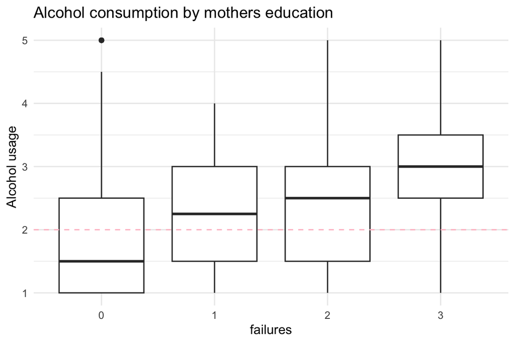

```r
ggplot(data=alc, aes(x=factor(failures),y=alc_use))+
  geom_boxplot()+
  geom_hline(yintercept = 2,linetype="dashed", color="pink")+
  labs(y="Alcohol usage", x="failures", title = "Alcohol consumption by mothers education")+
  theme_minimal()
```

The figure above supports the hypothesis that failures is positively correlated with alcohol usage. Nearly all of the student in failure category 3 or more use alcohol more than the limit for high usage. But again after checking the number of students in that category we find that they are very rare cases.

```r
tabyl(alc$failures)
```

```
##  alc$failures   n    percent
##             0 325 0.87837838
##             1  24 0.06486486
##             2  17 0.04594595
##             3   4 0.01081081
```

### Quality of family relationships

Check first the distribution of student to the categories. No using for visuals instead of cross tabulations:

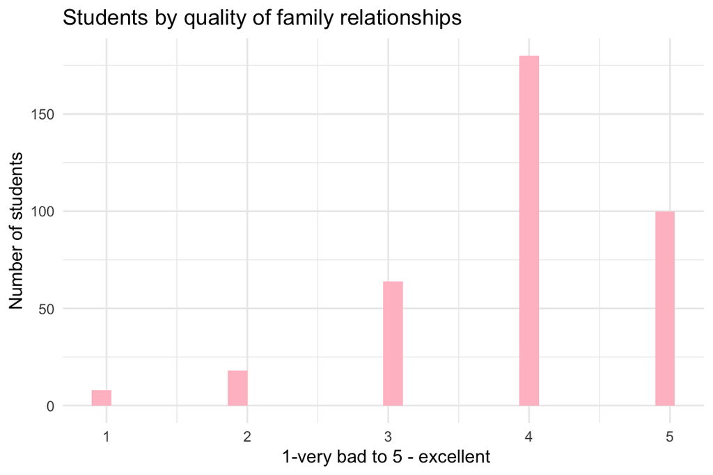

```r
ggplot(data=alc, aes(x=famrel))+
  geom_histogram(fill="pink") +
  labs(y="Number of students", x=" 1-very bad to 5 - excellent", title = "Students by quality of family relationships")+
  theme_minimal()
```

We see that most of the students have quite good family relationships. Lets then check how alcohol usage is distributed in each of these categories

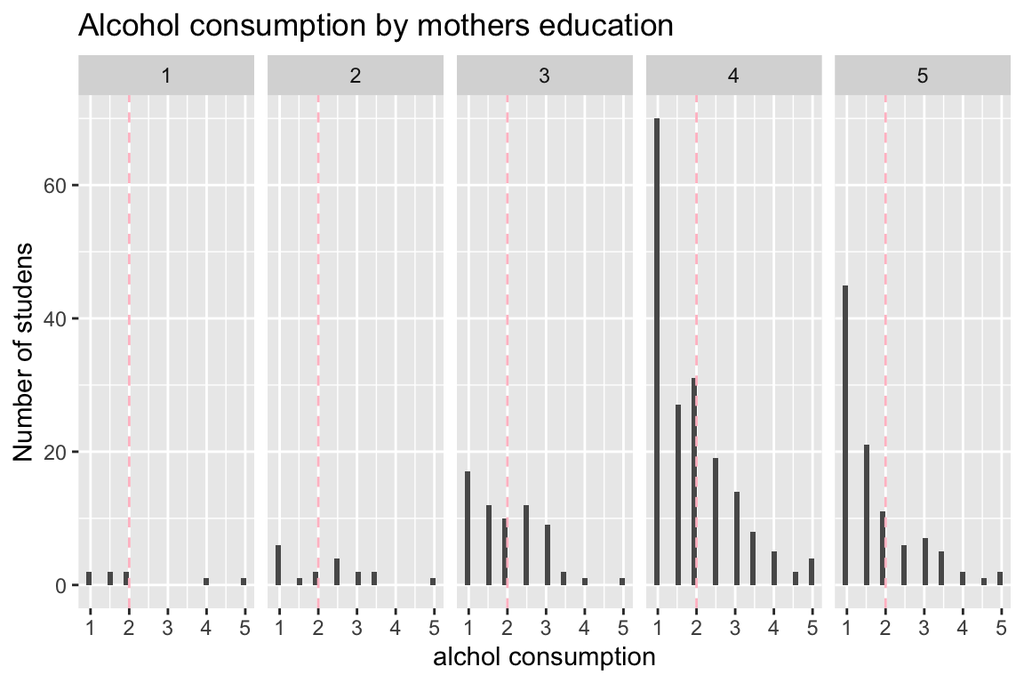

```r
ggplot(data=alc, aes(x=alc_use))+
  geom_histogram()+
  geom_vline(xintercept = 2,linetype="dashed", color="pink")+
  labs(y="Number of studens", x="alchol consumption", title = "Alcohol consumption by mothers education")+
  facet_grid(~famrel)
```

Above we see that on the contrary to my hypothesis it doesn’t seem that alcohol consumption would be higher when the quality of family relationships are lower. At least in the sample most of students using a lot are in the panes 3 to 5.

### Free-time

Finally lets check free time after school and alcohol consumption.

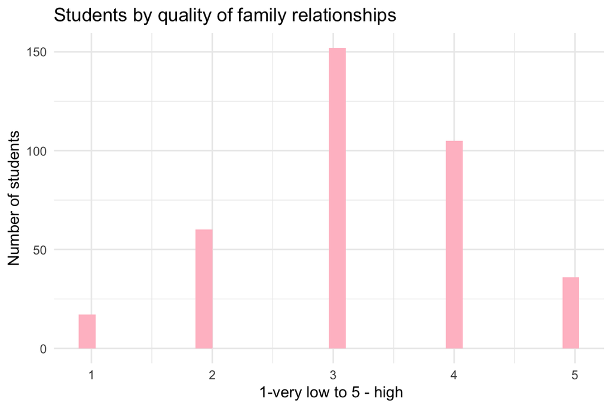

```r
ggplot(data=alc, aes(x=freetime))+
  geom_histogram(fill="pink") +
  labs(y="Number of students", x=" 1-very low to 5 - high", title = "Students by quality of family relationships")+
  theme_minimal()
```

Bulk of the students are in the middle of the scale.

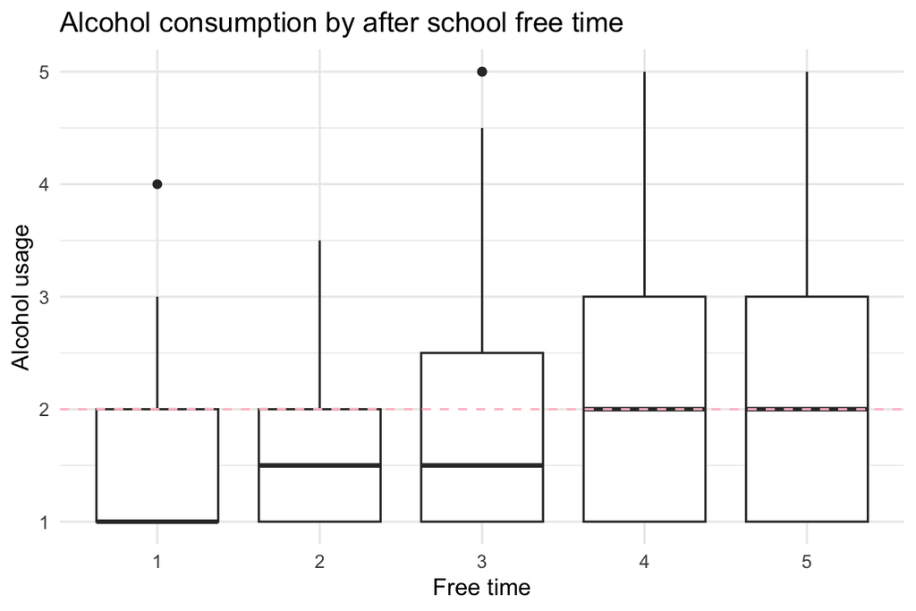

```r
ggplot(data=alc, aes(x=factor(freetime),y=alc_use))+
  geom_boxplot()+
  geom_hline(yintercept = 2,linetype="dashed", color="pink")+
  labs(y="Alcohol usage", x="Free time", title = "Alcohol consumption by after school free time")+
  theme_minimal()
```

From the above we see that alcohol consumption is on average higher for students with lots of after school free time. Perhaps students with low free time spend all their time at sports or similar activities and don’t simply have time to drink.

## Logistic regression

### Estimating the model

```r
model <- glm(high_use ~ Medu + failures + famrel + freetime ,family=binomial(link='logit'),data=alc)
summary(model)
```

```
##
## Call:
## glm(formula = high_use ~ Medu + failures + famrel + freetime,
##     family = binomial(link = "logit"), data = alc)
##
## Coefficients:
##             Estimate Std. Error z value Pr(>|z|)
## (Intercept) -1.17191    0.68276  -1.716  0.08608 .
## Medu         0.06345    0.11284   0.562  0.57391
## failures     0.65300    0.20884   3.127  0.00177 **
## famrel      -0.33425    0.12817  -2.608  0.00911 **
## freetime     0.39702    0.12509   3.174  0.00150 **
## ---
## Signif. codes:  0 '***' 0.001 '**' 0.01 '*' 0.05 '.' 0.1 ' ' 1
##
## (Dispersion parameter for binomial family taken to be 1)
##
##     Null deviance: 452.04  on 369  degrees of freedom
## Residual deviance: 423.92  on 365  degrees of freedom
## AIC: 433.92
##
## Number of Fisher Scoring iterations: 4
```

### Prediction vs. actual

```r
alc <- mutate(alc, probability = predict(model, type = "response"))
alc <- mutate(alc, prediction = probability > 0.5)


tabyl(alc, high_use,prediction)
```

```
##  high_use FALSE TRUE
##     FALSE   244   15
##      TRUE    95   16
```

It seems that model does pretty good job of predicting non-high-users: 259 non-high-users the models predicts 244 correctly. On the other hand the model is terrible predicting the high-users. From 111 high users in the sample it predicts correctly only 16.

### The total proportion of inaccurately classified individuals

```r
inaccurate <- nrow(alc %>% filter(high_use!=prediction))
all <- nrow(alc)

inaccurate/all
```

```
## [1] 0.2972973
```

The total proportion is of inaccurately classified individuals is around 30 percent. This is definitely improvement for a single coin toss strategy.